# One-way ANOVA

## Slugit

Garden slugs of the same species and approximately the same size were given either a full dose, a half strength dose, or a one tenth strength dose of a molluscicide (‘Slugit’) dissolved in water. A control group were treated with just water. The rate of movement of the slugs on a moist wooden board after treatment was recorded (cm per min). There were 8 replicate slugs for each treatment.

The data are stored in a CSV file SLUGIT.CSV. The rate of movement is stored in the `Distance` variable and the treatment codes are in the `SlugitTreat` variable (levels: ‘full dose’, ‘half dose’, ‘one tenth dose’, ‘control’).

### First steps

As always start by loading the necessary packages.

```r
library(readr)
library(dplyr)
library(ggplot2)
library(agricolae)
```

Either create an RStudio project or set your working directory to the folder containing the data set that you want to work with. Then read the data into R (remember to assign it a name):

```r
slug <- read_csv("SLUGIT.CSV")
```

Start by having a quick look at the data. How many variables are there? How many observations? Is the focal variable (`Distance`) on a ratio or interval scale?

```r
glimpse(slug)
```

```
## Rows: 32
## Columns: 2
## $ Distance    <dbl> 3.6, 4.1, 2.5, 4.9, 3.4, 3.4, 2.5, 2.7, 3.9, 3.7, 2.8, 3.…
## $ SlugitTreat <chr> "full dose", "full dose", "full dose", "full dose", "full…
```

Remember that for a one-way ANOVA the independent variable which encodes the treatments must not be stored as numbers (i.e. do not call the treatments “1, 2, 3,…”). Using a numeric variable will result in a linear regression being fitted, rather than an ANOVA. In this example, the `SlugitTreat` variable takes values such as ‘full dose’ so we don’t need to worry about this problem. However, if the treatments had been encoded as numbers we should use `mutate` to convert `SlugitTreat` to an R factor before doing anything else, e.g.

```r
slug <- mutate(slug, SlugitTreat = factor(SlugitTreat))
```

The one-way ANOVA also requires that the experimental units are independent. This assumption should have been considered earlier, as part of the experimental design.

### Visualising the data

Next make a quick plot of the data (either a box and whiskers plot as below or a separate dot plot for each group).

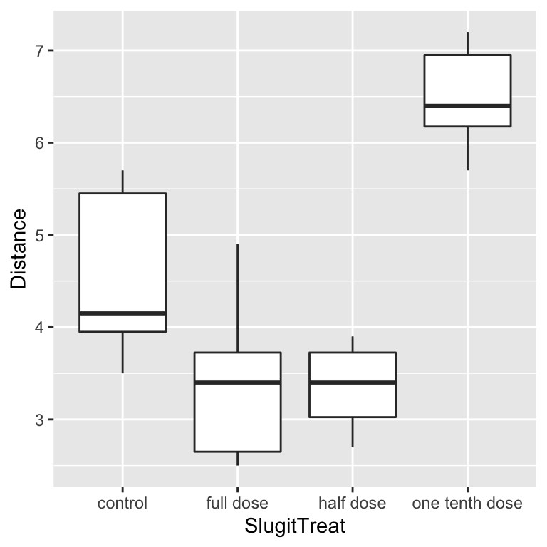

```r
ggplot(slug, aes(x = SlugitTreat, y = Distance)) +
  geom_boxplot()
```

The main thing to do here is use the plot to understand the patterns in the data. It looks like both a full dose and half dose reduce the movement rate of slugs (relative to the control). This suggests that ‘slugit’ might be an effective molluscicide. However, 1/10 dose actually caused the slugs to move more. Ask yourself, do these patterns make sense?

We can also use the plot to very roughly evaluate two of the assumptions of one-way ANOVA, i.e. that the within-group variance is roughly constant and that the dependent variable is normally distributed within each group. Here, the variability within each group appears roughly similar. The distributions also look roughly symmetrical and there are no ‘outliers’, suggesting that the normal distribution assumption is not violated.

It’s OK to quickly check assumptions this way, but you should always evaluate them properly by plotting the model diagnostics once the model has been fitted.

### Fitting the model

Fit the model using the `lm` function, which takes a formula and a data frame containing the variables in the formula as its two arguments. Remember that in the formula the dependent variable and the treatment go on the left and right of the `~`, respectively. Don’t mix these positions up!

```r
slug_model <- lm(Distance ~ SlugitTreat, data = slug)
```

### Check the model diagnostics

Check the model diagnostics **before** looking at the statistical output. This is important. There is no point worrying about *p*-values until you’re convinced the assumptions of a model have been met.

Check the normality assumption using a normal probability plot. Here, if the residuals are normally distributed they will be positioned near the dashed line. Note that we don’t expect to see a perfect relationship, but the majority of the points should be close to the line.

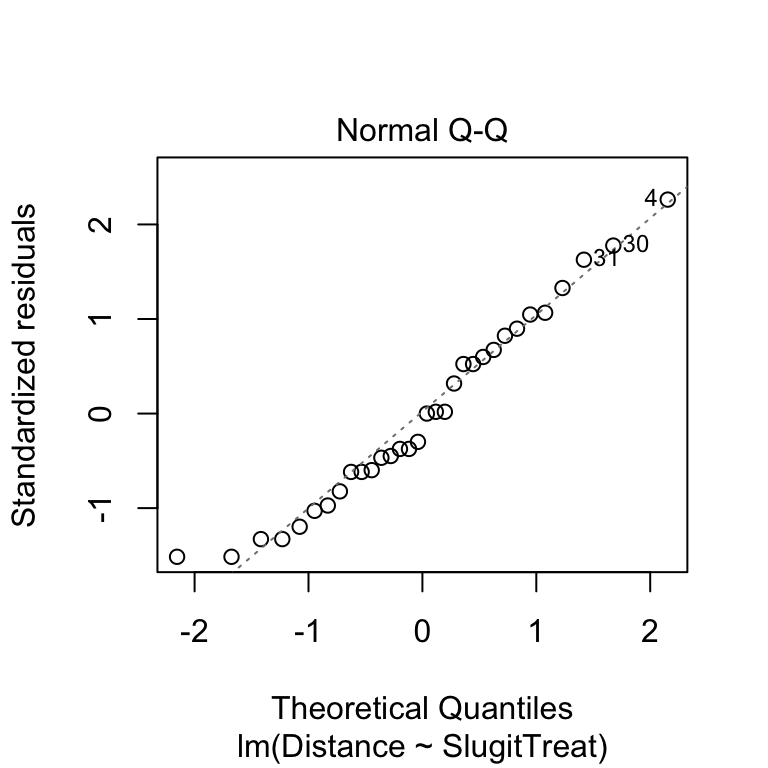

```r
plot(slug_model, which = 2)
```

This plot looks fine - the points don’t deviate from the line in any systematic way.

Finally, check the constant variance assumption using a scale-location plot. Ideally there should be a flat relationship between the transformed residuals (y-axis) and the fitted values (x-axis). If the magnitude of the residuals either increases or decreases as the fitted values increase then the constant variance assumption is violated.

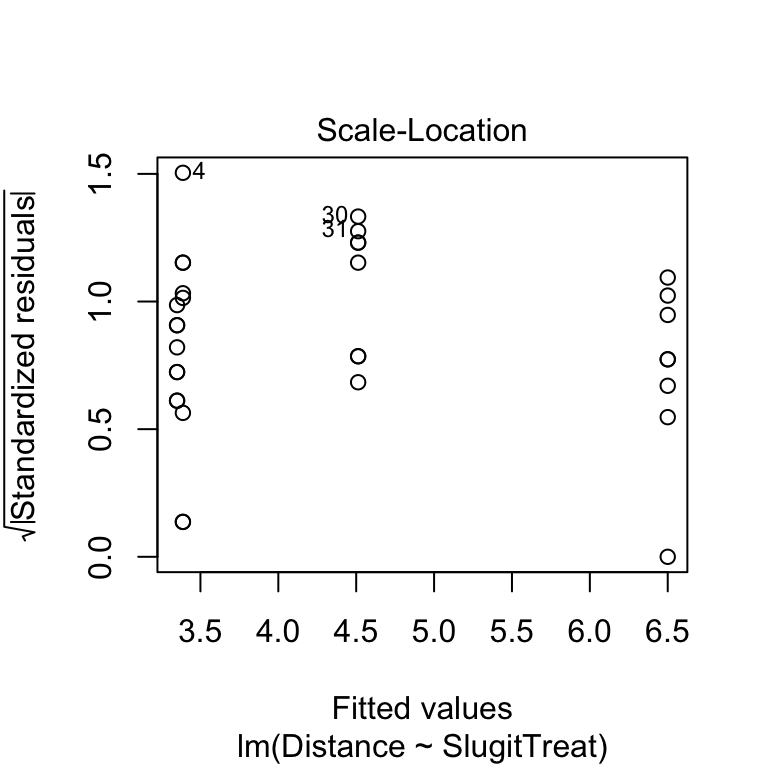

```r
plot(slug_model, which = 3, add.smooth = FALSE)
```

There doesn’t appear to be a systematic pattern in the residuals here so the constant variance assumption is met.

Remember that if the data do not fit the assumptions of the one-way ANOVA the focal variable can be transformed. After fitting the model to the transformed data remember to check the diagnostics again to see if the assumptions are now met. If the assumptions are still not met it may be possible to use a non-parametric test instead. The non-parametric equivalent to a one-way ANOVA is the Kruskal-Wallis test.

### Statistical output

Assuming the model assumptions were not violated now look at the model output. Use the `anova` function to calculate the F-ratio. This function takes the name of the fitted model as its only argument.

```r
anova(slug_model)
```

```
## Analysis of Variance Table
##
## Response: Distance
##             Df Sum Sq Mean Sq F value    Pr(>F)
## SlugitTreat  3 52.358 17.4525  34.179 1.692e-09 ***
## Residuals   28 14.298  0.5106
## ---
## Signif. codes:  0 '***' 0.001 '**' 0.01 '*' 0.05 '.' 0.1 ' ' 1
```

The table summarises the different parts of the *F*-test calculations: `Df` – degrees of freedom, `Sum Sq` – the sum of squares, `Mean Sq` – the mean square, `F value` – the *F*-statistic, `Pr(>F)` – the p-value. The *F*-statistic is the key term; larger values of the *F* statistic indicate clearer differences among the means of the different treatment groups. The p-value gives the probability that the observed differences between the means, or a more extreme difference, could have arisen through sampling variation under the null hypothesis. What is the null hypothesis: it is one of no effect of treatment, i.e. the null hypothesis is that all the means are the same. A p-value of less than 0.05 indicates the result is statistically significant (i.e. that there is a significant difference between the means of different treatment groups). Here, there does appear to be a significant effect of molluscicide dosage on slug activity as p<0.001.

Also make a note of the degrees of freedom, as these should be included in the results.